# Maps of Health Environment Distribution in Florida

[Rory Renzy](https://ncfpbl.github.io/author/rory-renzy/)

05/15/2020

# Overview and Data

During this spring semester, I wanted to build on the work I had done in mapping and getting a better understanding of the distribution of health data in Florida, by county. The previously used FL CHARTS website has data available on things related to health, but not necessarily regarding resources. I title this as “health environment” data. This data is available under the [Florida Environmental Public Health Tracking](https://www.floridatracking.com/healthtracking/) tool. The state collects a wealth of information on health, and makes it all public available in the form of `.csv` files. First, I will walk you through how to locate data on the website and use it to make maps. The above link will take you to the homepage, which provides avenues to all sorts of publicly available Florida health data, this time regarding health *environments*.

[figure not shown]

I decided to choose the distance to health food sources, proximity to busy roadways, number of very hot days, infant mortality, COPD hospitalizations, and the percentage of vacant homes. All of the data used in this report are from the most recently available uploads, from 2019. To locate each set of data, click on the toolbar on the left-hand side of the homepage.

Firstly, appropriate packages must be installed and/or updated. Relavant packages include `tidyverse`, `tigris`, `rgeos`, `rdgal`, and `taRifx`. I then load in packages and read in my data. The original .xls files for this data are a little wonky, with some strange formatting that couldn’t easily be resolved in R. Therefore, I cleaned the spreadsheets for my various datasets, saved them as .csv files, and read them in that way. I would recommend this for future Florida Environmental Public Health Tracking use.

The county-level data from FLorida Environmental Public Health Tracking already has `fips` codes loaded with the data. Therefore, there is no need to manually assign the values to each county in an R code chunk.

# Making the Map

Now, the fun part: actually drawing the maps! Next, the FL shapefiles need to be loaded and fortified to create the outline for the maps.

```r
library(dplyr)
library(tigris)
```

Since the data we are using involves mapping into county shapefiles, we use the below code to pull down the FL county shapefiles from the `tigris` package.

```r
florida_counties <- counties(12, cb=TRUE)
```

We conclude this section by making our shapefiles usable, by `fortifying` them.

```r
library(rgeos)
library(rgdal)
library(taRifx)

florida_counties$fips <- destring(florida_counties$GEOID)
fortified_fl_counties <- fortify(florida_counties, region = "fips")
```

## Healthy Food Sources

The ability one has to access, purchase, and eat healthy food can go a long way in helping them develop healthy lifestyles and escape cycles of poverty and illness. More and more, we see SNAP recipients using their benefits at farmers markets and other sources of healthy food (Farmers Market Coalition). This has been made even easier by the advent of the EBT card, which allows for more discrete use of benefits and overall lowered social stigma.

The map below is interesting, as it appears that the most populous part of the state (the tri-county area of Palm Beach, Broward, and Miami-Dade counties), in absolute terms, has the highest percentage of people living within a half mile of a healthy food source. However, since the measurement of analysis is so small (only a half mile), more granular data would be more useful in assessing the existence of food deserts in neighborhoods (Walker, Keane, and Burke 2010). Even the Florida Environmental Public Health Tracking service notes “Identifying food deserts where healthy food sources are scarce and unhealthy food options are plentiful can help us understand the choices people make and how it contributes to public health.” This is also important in the Panhandle, where it appears that no one has access to healthy food, but the situation that people just live really far apart from one another is more likely.

What implications does this have for politics and policy? More granular data would be helpful to pinpoint where food and health policy could be best targeted. For example, scholars emphasize communities of color and low-income communtities. It is also important to take into consideration the ways healthy food access could work in different types of areas, like the widespread population of northern Florida and the dense areas in the South.

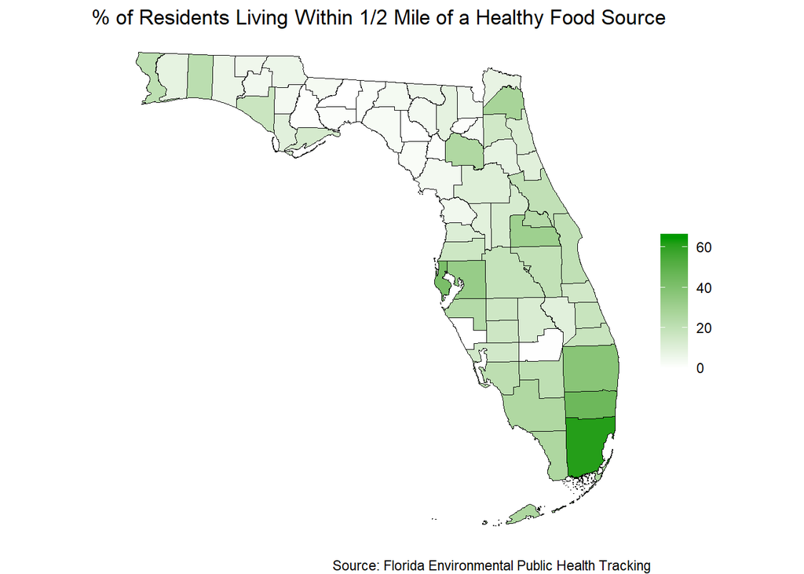

## Proximity to Roadways

Similar to the above `healthy food sources` map, this map could be improved with more granular data, at the neighborhood level. Otherwise, we are essentially looking at population data; notice the larger percentages around the tri-county area, Orlando, Tampa, and Jacksonville, for example. The size of the measurement (500 feet) is also fairly small, but is likely a reasonable length for which health effects to still be noticeable. This could include impacts on pregancy, similar to the air pollution that can impact pregnant women close to energy sites (Miranda et al. 2013).

There is likely an intersection between proximity to roadways and the kind of housing one lives in - is is more exposed to pollution? I wonder whether or not highways should be weighted higher than a typically busy roadway in a certain part of a town, and how the location of traditionally marginalized communities near highways (as a function of political decisions during the New Deal era) has resulted in health and political perception outcomes to this day. I additionally would be interested in understanding the tenuous relationship of having presumably cleaner air in the Panhandle, but also worse health outcomes. Is lack of abundant medical care generally to blame?

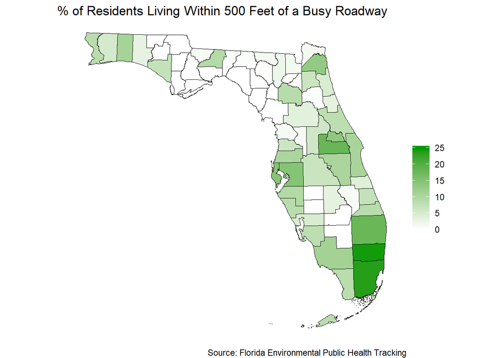

## Exposure to Heat

I have included this map as a proxy for the issues that can arrive in excessively hot areas. We see that counties in the the middle portion of the state, going vertically, have anywhere from 75 to 100 days of 90 degrees and above per year. This map is interesting to me for its intersection with what many might consider to be a literal life-saver in Florida: air conditioning.

A lack of air conditioning has grown more and more prominent, especially in the South. Florida is one of the few states that does not mandate air conditioning in its prison facilities (Edwards and Medlock 2016). It would not surprise me if many of such facilties are located in the greenest counties, saying a lot about the political treatment of prisoners in the state. Additionally, in economically disadvantaged areas, which can be understood at the county level (but would be stronger with smaller geographies), retrofitting buildings to be green and have air conditioning as a guarantee could be useful political considerations in the future (Phillips 2018). This would not help in creating healthier and safer environments, but also ones in policymakers are responsive to the basic needs of their constituents.

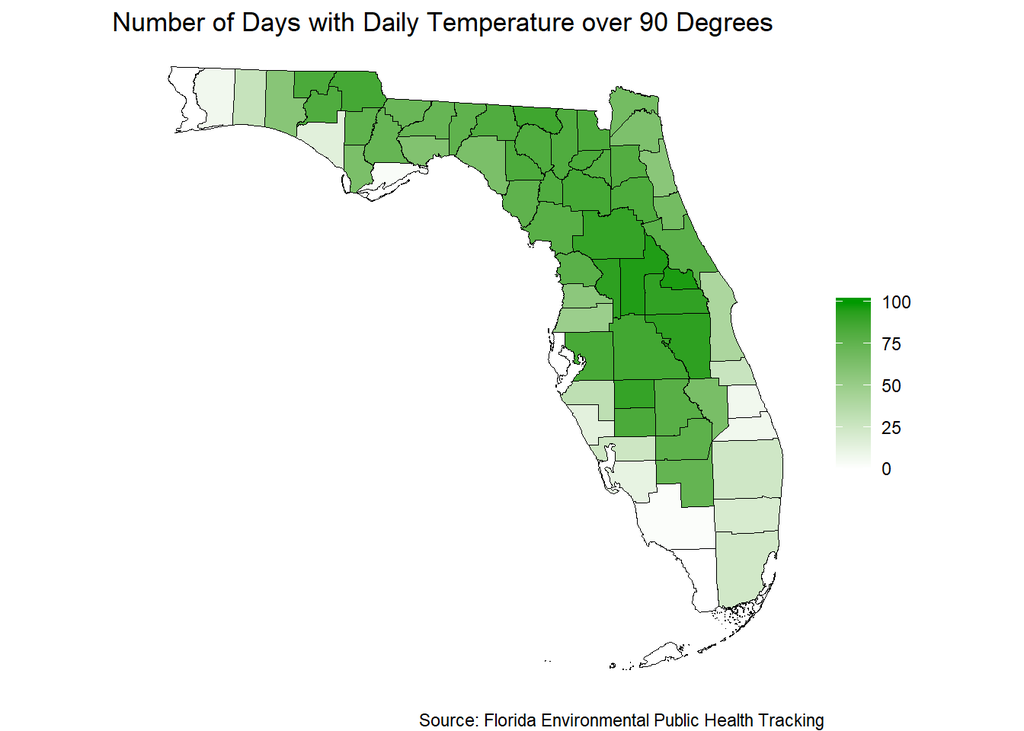

## Infant Mortality

This does the trick, and allows us to see broader patterns in the Panhandle area of the state. Here, as is the case in the `Health Resources` maps, the crude infant mortality rate is higher relative to the rest of the state (save Glades County). This acts as a general indicator that the health environment, from access to health care to the quality of living in general, in the Panhandle is, again, less than that of the rest of the state.

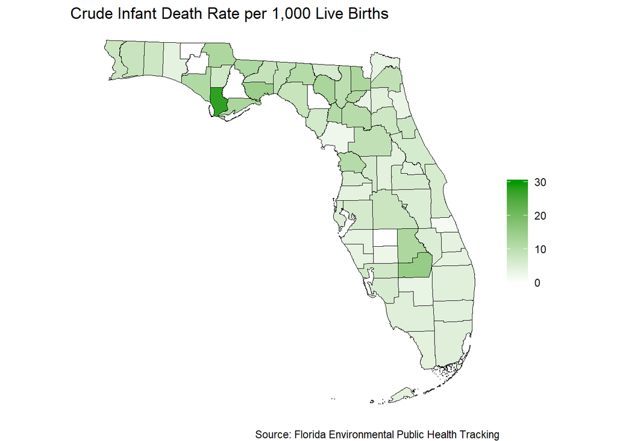

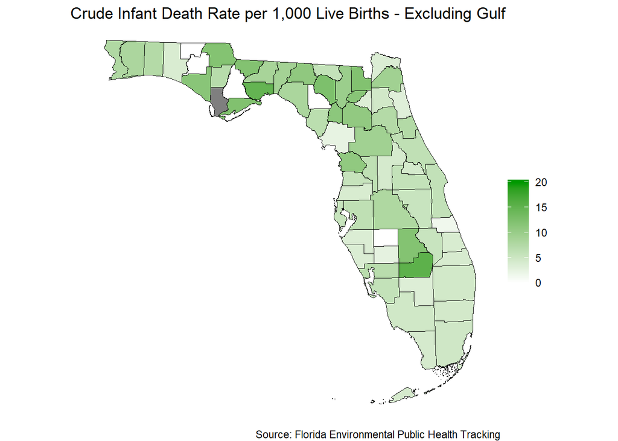

```r
inf_gulf <- infants
inf_gulf$Rate[inf_gulf$County=="Gulf"] <- NA
```

## COPD Hospitalizations

I have less commentary here than on other maps - it is more so included due to the relevance it has to the COVID-19 pandemic. Pre-existing conditions worsen the impact of the virus, and respiratory conditions like COPD can be the most worrisome in this regard. I wonder how, when the virus is mitigated and all the data collected, how the overlapped maps between COPD and COVID would look. Another thing to consider is the variable at play here: COPD *hopsitalizations*, not COPD cases or doctor visits. The greater frequency where health care resources are few and far between create a health environment where going to the hospital is, unfortunately, the norm.

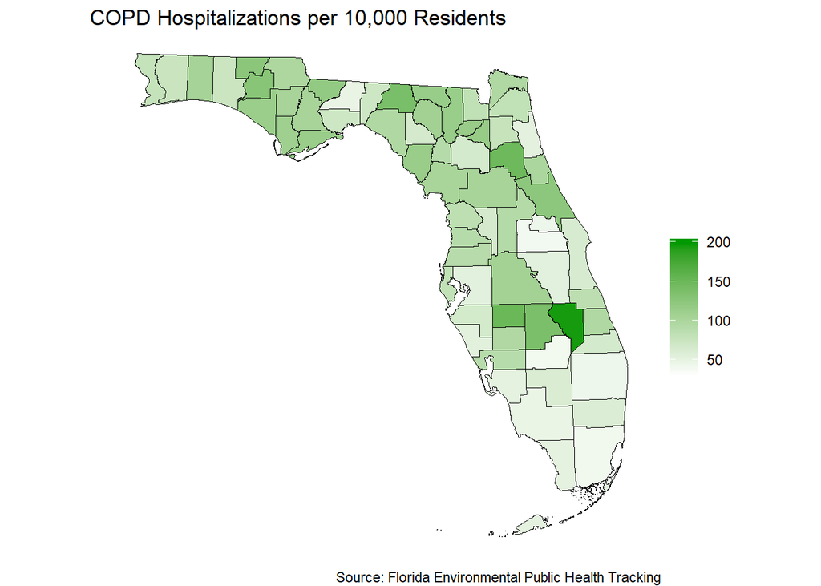

## Vacant Housing

The percentage of housing vacant in a given county (or any geographic area) can normally act as a proxy for the economic health of the area, and by extension the health environment that one lives in. The [US Census Bureau](https://www.census.gov/housing/hvs/index.html) tracks the amount of housing that is vacant through both the American Community Survey and more-detailed housing related surveys. According to the Bureau’s codebook (found at the above link), housing units are considered vacant if they are empty year-round, the majority of its inhabitants live in permanent residences elsewhere, or the construction of the unit has reached the point where the doors and walls are fully installed.

Therefore, I theorize that the vacancy we see in the map of Florida (for example, the high levels in Collier and Monroe County, with the latter having the Keys) are due to a reason different from the abandoned neighborhoods in the Midwest that succumbed to the powers of deindustrializion in the 1970s (Florida 2018). Snowbirds, and tourism more broadly, are likely what is making Florida seem so vacant, primarily in the South. This could be different from the vacancy rates toward the northern part of the state, which may be due to less development in rural areas overall, but also tourist hotspots along the Panhandle coast. Policymakers, more on the local scale, are coming to grips with the problems that emerge when trying to balance affordable housing, using the units that are already available, and housing prices that keep rising when the stock becomes smaller and smaller due to vacation rentals (Gross 2019). I’m not exactly sure what conclusions to come to as far as housing as a health environment in Florida, but this has raised issues from a new angle I hadn’t previously thought about.

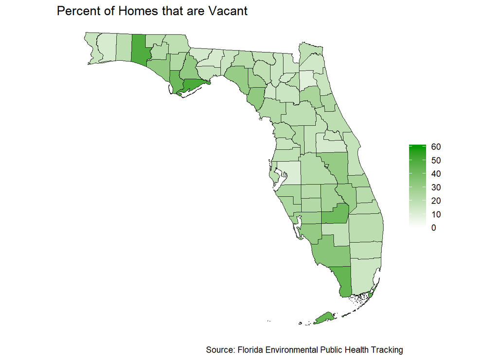

# Conclusion

These preliminary maps provide a good first look at the distribution of health environmental conditions across Florida’s counties. Understanding these conditions should be useful to policymakers in assessing needs of residents in each county, as well as the general state of being of the populace. If you have any questions, feel free to reach out to me at rory.renzy17@ncf.edu.

# Sources

Access to Healthy Food and Why It Matters: A Review of the Research. (2013). *PolicyLink* [Link](http://thefoodtrust.org/uploads/media_items/access-to-healthy-food.original.pdf)

Edwards, J., & Medlock, S. (2016). Air Conditioning Is a Human Right. *TIME* [Link](https://time.com/4405338/air-conditioning-human-right/)

Florida, R. (2018). Vacancy: America’s Other Housing Crisis. *CityLab* [Link](https://www.citylab.com/equity/2018/07/vacancy-americas-other-housing-crisis/565901/)

Gross, Samantha J. (2019). How much vacant housing is there in Florida? You asked, we answered. *The Miami Herald* [Link](https://www.miamiherald.com/news/politics-government/influencers/article233627502.html)

Housing Vacancies and Homeownership (CPS/HVS) *United States Census Bureau* [Link](https://www.census.gov/housing/hvs/index.html)

Infant Mortality Rate (The World Factbook) *CIA* [Link](https://www.cia.gov/library/publications/the-world-factbook/fields/354.html)

Miranda, M. L., Edwards, S. E., Chang, H. H., & Auten, R. L. (2013). Proximity to roadways and pregnancy outcomes. *Journal of Exposure Science and Environmental Epidemiology 23*, 32-38.

Phillips, L. (2018). In Defense of Air-Conditioning. *Jacobin* [Link](https://jacobinmag.com/2018/08/air-conditioning-climate-change-energy-pollution)

Supplemental Nutrition Assistance Program *Farmers Market Coalition* [Link](https://farmersmarketcoalition.org/advocacy/snap/)

Walker, R. E., Keane, C. R., & Burke, J. G. (2010). Disparities and access to healthy food in the United States: A review of food deserts literature *Health & Place 16*, 876-884. [Link](https://www-sciencedirect-com.ezproxy.lib.usf.edu/science/article/pii/S1353829210000584)